# Bias and uncertainty in estimating length with DJI Mini 2

Ana Eguiguren

2023-09-06

## Callibration data

This Dataset has 426 images of Balaena taken during different flights and dates.

- altitudeRaw: the altitude indicated by DJI (zeroed at takeoff).
- imageWidth: picture’s width in pixels (1920 or 3840).
- pixel.length: Balaena’s length in pixels.
- position: whether Balaena was in the center of the frame (pos_c) or closer to the edges (pos_o).

```r
head(dat)
```

```
##         Date FlightNo                          imageName timeStamp altitudeRaw
## 1 2023-04-08      198 DJI_0005.MP4_00_00_02_vlc00001.png      0:02        50.4
## 2 2023-04-08      198 DJI_0005.MP4_00_00_04_vlc00002.png      0:04        49.7
## 3 2023-04-08      199 DJI_0006.MP4_00_03_03_vlc00001.png      3:03       119.4
## 4 2023-04-08      199 DJI_0006.MP4_00_03_11_vlc00002.png      3:11       120.1
## 5 2023-04-08      199 DJI_0006.MP4_00_03_14_vlc00003.png      3:14       120.3
## 6 2023-04-08      199 DJI_0006.MP4_00_03_16_vlc00004.png      3:16       119.7
##   imageWidth pixel.length position
## 1       3840     654.6037    pos_c
## 2       3840     672.1734    pos_c
## 3       3840     282.6148    pos_o
## 4       3840     282.4793    pos_o
## 5       3840     283.7345    pos_o
## 6       3840     287.1069    pos_o
```

## Correct initial altitude

The drone altitude is zeroed the moment the rotors start, which means that the true altitude needs to add the distance from the drone’s launch point to the water:

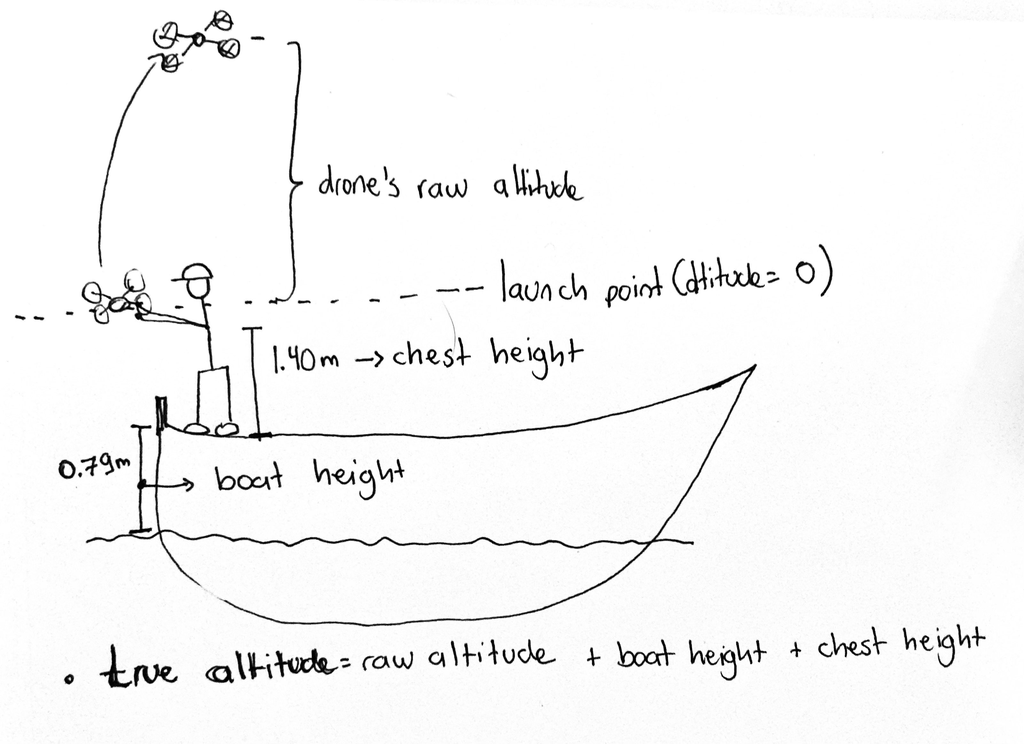

*note that, in Balaena’s case, the altitude we want is the distance from the drone to the boat, so we can omit the boat height in the calculation as follows:*

```r
#recalculate Balaena's length in m, with new altitude
boat.height = 1.03- 0.24# balaena's altitude over the water - toe rail

launch.chest = 1.4 # Mateo's chest height
camera.height = 0.045 # cameras distance above the base of the drone's legsfrom legs

dat$altitude.fix <- dat$altitude + launch.chest + camera.height
head(dat)
```

```
##         Date FlightNo                          imageName timeStamp altitudeRaw
## 1 2023-04-08      198 DJI_0005.MP4_00_00_02_vlc00001.png      0:02        50.4
## 2 2023-04-08      198 DJI_0005.MP4_00_00_04_vlc00002.png      0:04        49.7
## 3 2023-04-08      199 DJI_0006.MP4_00_03_03_vlc00001.png      3:03       119.4
## 4 2023-04-08      199 DJI_0006.MP4_00_03_11_vlc00002.png      3:11       120.1
## 5 2023-04-08      199 DJI_0006.MP4_00_03_14_vlc00003.png      3:14       120.3
## 6 2023-04-08      199 DJI_0006.MP4_00_03_16_vlc00004.png      3:16       119.7
##   imageWidth pixel.length position altitude.fix
## 1       3840     654.6037    pos_c       51.845
## 2       3840     672.1734    pos_c       51.145
## 3       3840     282.6148    pos_o      120.845
## 4       3840     282.4793    pos_o      121.545
## 5       3840     283.7345    pos_o      121.745
## 6       3840     287.1069    pos_o      121.145
```

Next, we use the following formula to calculate Balaena’s length according to the drone’s data: length = (alpha/image.width) * altitude * length.pixels

$$length = \frac{alpha}{image.width} \times true.altitude \times
pixel.length$$

Where *alpha* is the camera’s correction factor, estimated in the lab by measuring objects of known length and distance. This equation is reflected in the following function:

```r
morpho.length.alpha <- function(alpha = 1.2646,image.width, altitude, length.pixels){
  length = (alpha/image.width) * altitude * length.pixels
}
```

This results in the following estimated length for Balaena:

```r
dat$bal.length<- morpho.length.alpha(altitude = dat$altitude.fix,
                                      image.width = dat$imageWidth,
                                      length.pixels = dat$pixel.length)
summary(dat$bal.length)
```

```
##    Min. 1st Qu.  Median    Mean 3rd Qu.    Max.
##   9.457  11.212  11.493  11.458  11.754  12.966
```

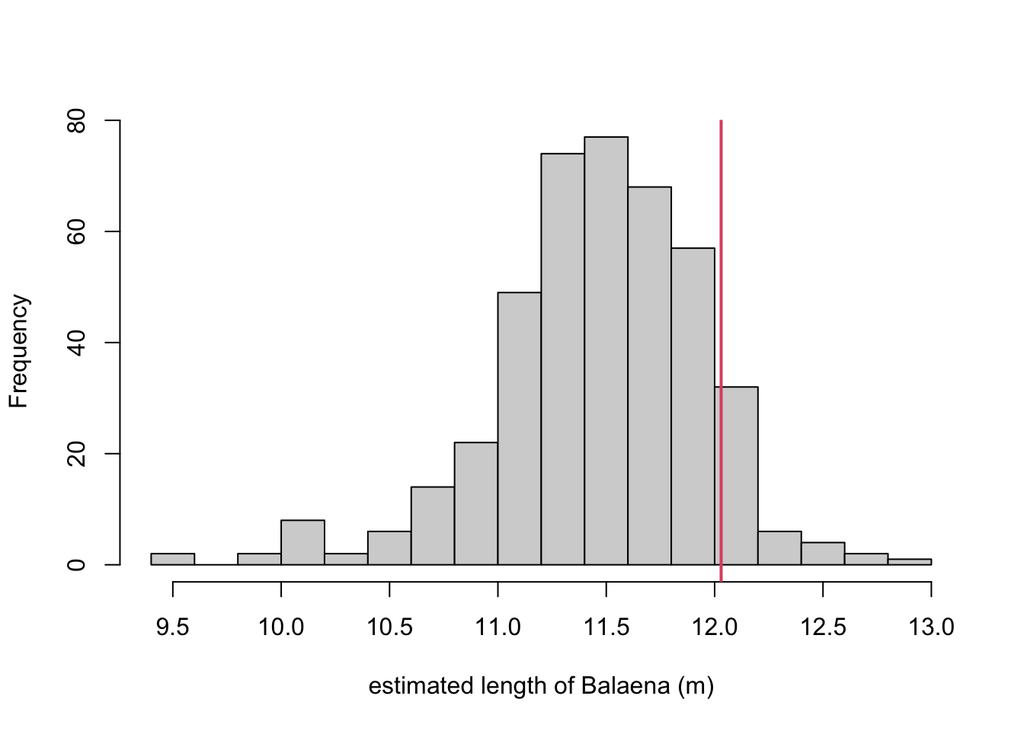

Histogram of Balaena’s length estimated using the DJI Mini Drone. The red line shows Balaena’s True length

```r
hist(dat$bal.length, breaks = 20, xlab = "estimated length of Balaena (m)", main = "")
abline(v = 12.03, col = 2, lwd = 2)
```

```r
dat$error <- dat$bal.length-12.03
mean(dat$error)
```

```
## [1] -0.5721738
```

```r
sd(dat$error)
```

```
## [1] 0.4805297
```

## Questions

- Am I doing something wrong? (in the formula?)
- If not, where should the correction factor go - is it a constant that I add to the total, or is it specifically for the altitude?

## Altitude experiment:

I suspect that the majority of the error comes from bad altitude estimates. So I used our knowledge of Balaena’s true length, assumed all other measurements were adequate, and calculated **true altitude**, and found that the good altitudes are further away from the measured altitudes at higher altitudes. For this, I used the formula:

$$true.altitude = \frac{true.length}{pixel.length} \times
\frac{image.width}{alpha}$$

```r
true.altitude <- function(true.length, pixel.length, image.width, alpha){
  t.a = (true.length/pixel.length) * (image.width/alpha)
}

dat$true.altitude <- true.altitude(true.length = 12.03,
                                   pixel.length = dat$pixel.length,
                                   image.width = dat$imageWidth,
                                   alpha = 1.2646)
```

Next, I estimated the altitude error as:

```r
dat$altitude.err <- dat$true.altitude - dat$altitude.fix
dat$altitude.err.p <- dat$altitude.err/dat$true.altitude
```

Which results in the following error distribution:

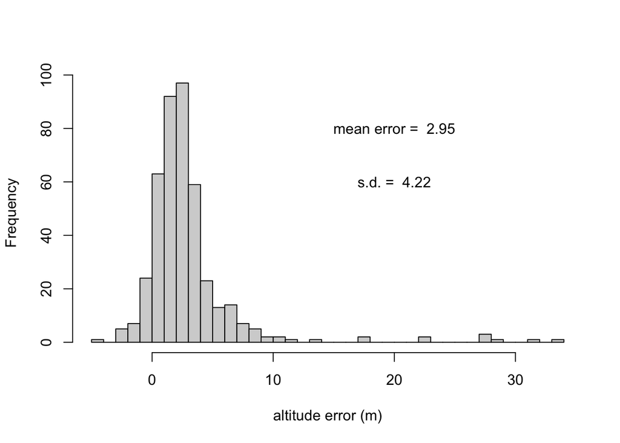

```r
hist(dat$altitude.err, breaks = 30, xlab = "altitude error (m)",
     main = "")
text(x = 20, y = 80, paste("mean error = ",signif(mean(dat$altitude.err), digits =3)))

text(x = 20, y = 60, paste("s.d. = ",signif(sd(dat$altitude.err), digits =3)))
```

How does this look across altitudes?

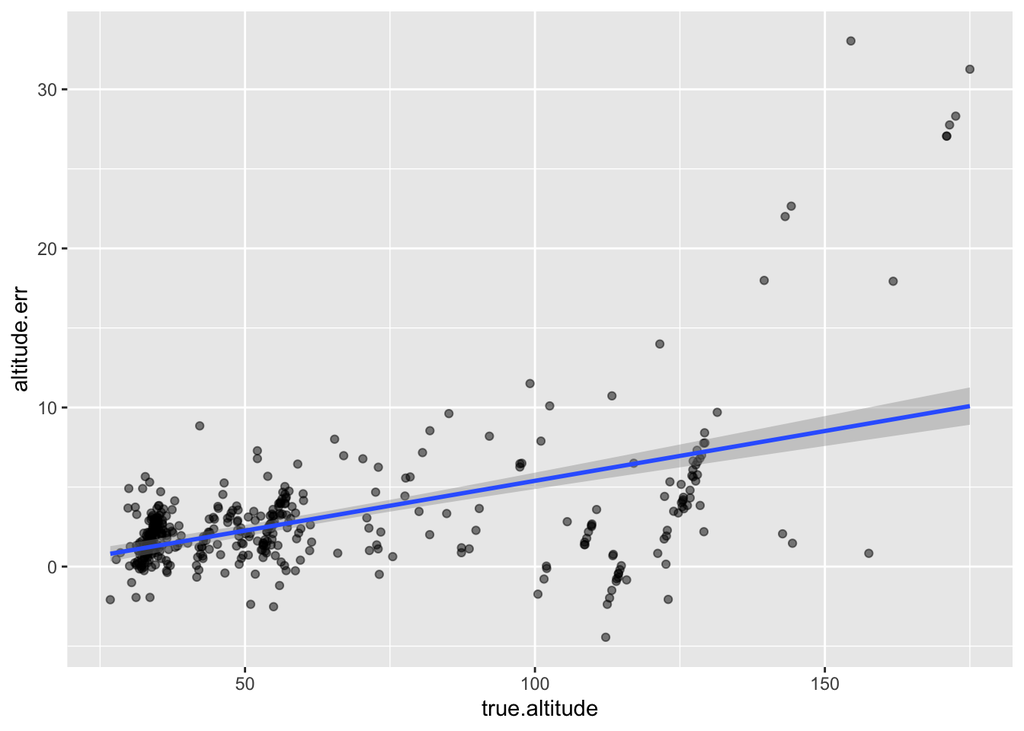

```r
ggplot(dat, aes(x = true.altitude, y = altitude.err))+
  geom_point(alpha = 0.5)+
  theme(legend.position = "none")+
  geom_smooth(method = "lm")
```

How does **percent** error compare to altitude?

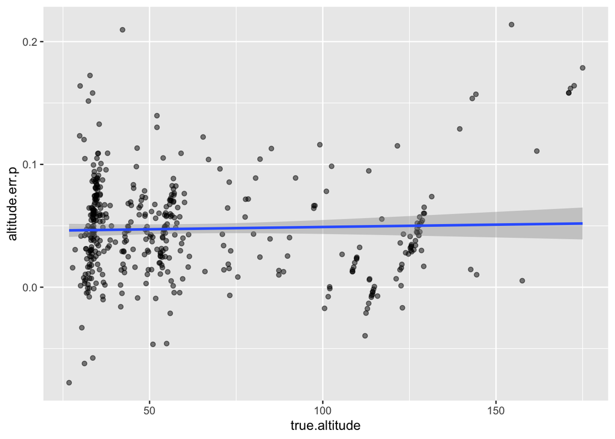

```r
ggplot(dat, aes(x = true.altitude, y = altitude.err.p))+
  geom_point(alpha = 0.5)+
  theme(legend.position = "none")+
  geom_smooth(method = "lm")
```

Which looks like error is proportional, more than an added constant

```r
mean(dat$altitude.err.p)
```

```
## [1] 0.04756224
```

```r
quantile(dat$altitude.err.p, probs = c(0.05, 0.95))
```

```
##           5%          95%
## -0.007102842  0.114652934
```

So if I add this percent altitude to my correction:

```r
dat$altitude.corr <-dat$altitude.fix*(1+mean(dat$altitude.err.p))


dat$bal.length.c<- morpho.length.alpha(altitude =dat$altitude.corr,
                                      image.width = dat$imageWidth,
                                      length.pixels = dat$pixel.length)
quantile(dat$bal.length.c, probs = c(0.05, 0.5, 0.95))
```

```
##       5%      50%      95%
## 11.15730 12.03968 12.69169
```

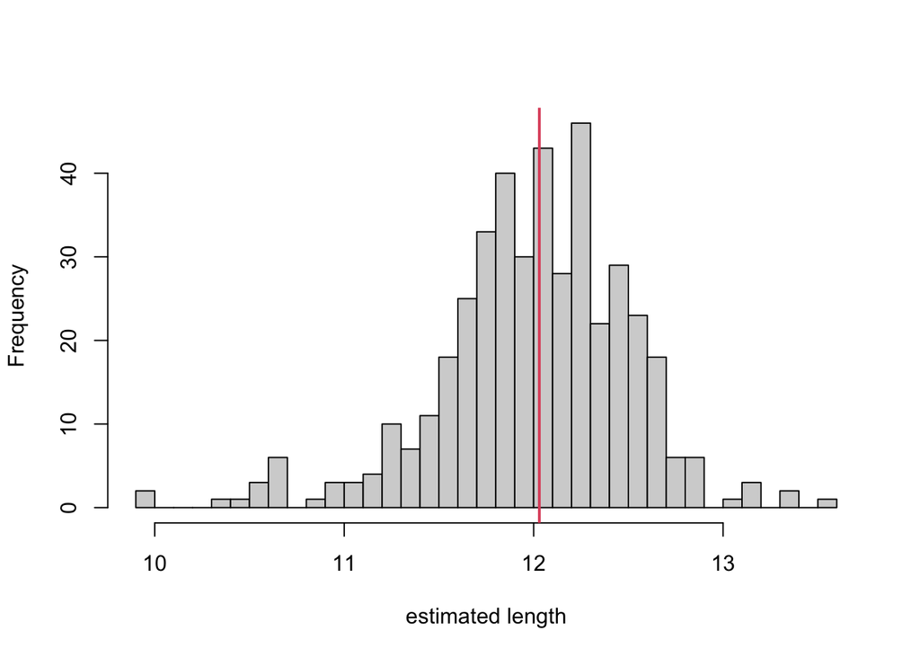

```r
hist(dat$bal.length.c, breaks = 30, main = "", xlab = "estimated length")
abline(v = 12.03, col = 2, lwd = 2)
```

Look at error pre & post correction

```r
dat$length.error.c <- dat$bal.length.c - 12.03 # corrected error raw
dat$length.error.c.p <- (dat$length.error.c/dat$bal.length.c)*100

dat$length.error.p <- (dat$error/dat$bal.length)*100

e <- c(dat$length.error.c.p,dat$length.error.p)
d <- data.frame(perc.error = e, error.type = rep(c("corrected", "uncorrected"), each = length(dat$bal.length)))
```

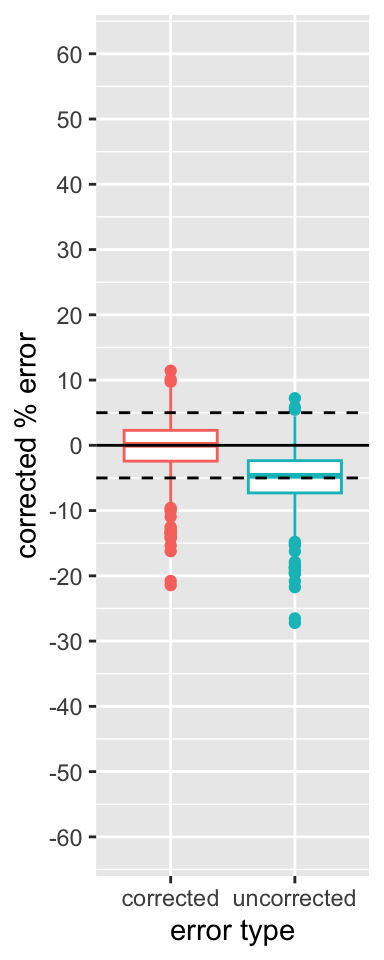

```r
ggplot(d, aes(x = error.type, y = perc.error, color = error.type))+
  geom_boxplot()+
    scale_y_continuous(limits=c(-60,60), breaks = seq(-60,60,10))+
  labs(y = "corrected % error", x = "error type")+
  theme(legend.position = "null")+
  geom_hline(yintercept = 0)+
  geom_hline(yintercept = -5, linetype = "dashed")+
  geom_hline(yintercept = 5, linetype = "dashed")
```